# Actividad 8 - Dense + Dropout + Batch Normalization

### Héctor Hibran Tapia Fernández - A01661114

### Problem Statement

Continuing with the same scenario, now that you have been able to successfuly predict each student GPA, now you will classify each Student based on they probability to have a successful GPA score.

The different classes are:

- Low : Students where final GPA is predicted to be between: 0 and 2
- Medium : Students where final GPA is predicted to be between: 2 and 3.5
- High : Students where final GPA is predicted to be between: 3.5 and 5

### 1) Import Libraries

First let's import the following libraries, if there is any library that you need and is not in the list bellow feel free to include it

```python
import numpy as np
import pandas as pd
import seaborn as sns
import tensorflow as tf
import matplotlib.pyplot as plt
from tensorflow.keras.layers import Dense
from tensorflow.keras.layers import Dropout
from tensorflow.keras.regularizers import l2
from tensorflow.keras.models import Sequential
from sklearn.model_selection import train_test_split
from sklearn.preprocessing import StandardScaler, LabelEncoder
from tensorflow.keras.layers import Conv1D, MaxPooling1D, Flatten
```

### 2) Load Data

- You will use the same file from the previous activity (Student Performance Data)

```python
data = pd.read_csv("Student_performance_data _.csv")
data
```

|  | StudentID | Age | Gender | Ethnicity | ParentalEducation | StudyTimeWeekly | Absences | Tutoring | ParentalSupport | Extracurricular | Sports | Music | Volunteering | GPA | GradeClass |
| --- | --- | --- | --- | --- | --- | --- | --- | --- | --- | --- | --- | --- | --- | --- | --- |
| 0 | 1001 | 17 | 1 | 0 | 2 | 19.833723 | 7 | 1 | 2 | 0 | 0 | 1 | 0 | 2.929196 | 2.0 |
| 1 | 1002 | 18 | 0 | 0 | 1 | 15.408756 | 0 | 0 | 1 | 0 | 0 | 0 | 0 | 3.042915 | 1.0 |
| 2 | 1003 | 15 | 0 | 2 | 3 | 4.210570 | 26 | 0 | 2 | 0 | 0 | 0 | 0 | 0.112602 | 4.0 |
| 3 | 1004 | 17 | 1 | 0 | 3 | 10.028829 | 14 | 0 | 3 | 1 | 0 | 0 | 0 | 2.054218 | 3.0 |
| 4 | 1005 | 17 | 1 | 0 | 2 | 4.672495 | 17 | 1 | 3 | 0 | 0 | 0 | 0 | 1.288061 | 4.0 |
| ... | ... | ... | ... | ... | ... | ... | ... | ... | ... | ... | ... | ... | ... | ... | ... |
| 2387 | 3388 | 18 | 1 | 0 | 3 | 10.680555 | 2 | 0 | 4 | 1 | 0 | 0 | 0 | 3.455509 | 0.0 |
| 2388 | 3389 | 17 | 0 | 0 | 1 | 7.583217 | 4 | 1 | 4 | 0 | 1 | 0 | 0 | 3.279150 | 4.0 |
| 2389 | 3390 | 16 | 1 | 0 | 2 | 6.805500 | 20 | 0 | 2 | 0 | 0 | 0 | 1 | 1.142333 | 2.0 |
| 2390 | 3391 | 16 | 1 | 1 | 0 | 12.416653 | 17 | 0 | 2 | 0 | 1 | 1 | 0 | 1.803297 | 1.0 |
| 2391 | 3392 | 16 | 1 | 0 | 2 | 17.819907 | 13 | 0 | 2 | 0 | 0 | 0 | 1 | 2.140014 | 1.0 |

2392 rows × 15 columns

```python
data.info()
```

```
<class 'pandas.core.frame.DataFrame'>
RangeIndex: 2392 entries, 0 to 2391
Data columns (total 15 columns):
 #   Column             Non-Null Count  Dtype
---  ------             --------------  -----
 0   StudentID          2392 non-null   int64
 1   Age                2392 non-null   int64
 2   Gender             2392 non-null   int64
 3   Ethnicity          2392 non-null   int64
 4   ParentalEducation  2392 non-null   int64
 5   StudyTimeWeekly    2392 non-null   float64
 6   Absences           2392 non-null   int64
 7   Tutoring           2392 non-null   int64
 8   ParentalSupport    2392 non-null   int64
 9   Extracurricular    2392 non-null   int64
 10  Sports             2392 non-null   int64
 11  Music              2392 non-null   int64
 12  Volunteering       2392 non-null   int64
 13  GPA                2392 non-null   float64
 14  GradeClass         2392 non-null   float64
dtypes: float64(3), int64(12)
memory usage: 280.4 KB
```

### 3) Add a new column called 'Profile' this column will have the following information

Based on the value of GPA for each student:

- If GPA values between 0 and 2 will be labeled 'Low',
- Values between 2 and 3.5 will be 'Medium',
- And values between 3.5 and 5 will be 'High'.

```python
data['Profile'] = pd.cut(data['GPA'], bins=[0, 2, 3.5, 5], labels=['Low', 'Medium', 'High'])
data.head(10)
```

|  | StudentID | Age | Gender | Ethnicity | ParentalEducation | StudyTimeWeekly | Absences | Tutoring | ParentalSupport | Extracurricular | Sports | Music | Volunteering | GPA | GradeClass | Profile |
| --- | --- | --- | --- | --- | --- | --- | --- | --- | --- | --- | --- | --- | --- | --- | --- | --- |
| 0 | 1001 | 17 | 1 | 0 | 2 | 19.833723 | 7 | 1 | 2 | 0 | 0 | 1 | 0 | 2.929196 | 2.0 | Medium |
| 1 | 1002 | 18 | 0 | 0 | 1 | 15.408756 | 0 | 0 | 1 | 0 | 0 | 0 | 0 | 3.042915 | 1.0 | Medium |
| 2 | 1003 | 15 | 0 | 2 | 3 | 4.210570 | 26 | 0 | 2 | 0 | 0 | 0 | 0 | 0.112602 | 4.0 | Low |
| 3 | 1004 | 17 | 1 | 0 | 3 | 10.028829 | 14 | 0 | 3 | 1 | 0 | 0 | 0 | 2.054218 | 3.0 | Medium |
| 4 | 1005 | 17 | 1 | 0 | 2 | 4.672495 | 17 | 1 | 3 | 0 | 0 | 0 | 0 | 1.288061 | 4.0 | Low |
| 5 | 1006 | 18 | 0 | 0 | 1 | 8.191219 | 0 | 0 | 1 | 1 | 0 | 0 | 0 | 3.084184 | 1.0 | Medium |
| 6 | 1007 | 15 | 0 | 1 | 1 | 15.601680 | 10 | 0 | 3 | 0 | 1 | 0 | 0 | 2.748237 | 2.0 | Medium |
| 7 | 1008 | 15 | 1 | 1 | 4 | 15.424496 | 22 | 1 | 1 | 1 | 0 | 0 | 0 | 1.360143 | 4.0 | Low |
| 8 | 1009 | 17 | 0 | 0 | 0 | 4.562008 | 1 | 0 | 2 | 0 | 1 | 0 | 1 | 2.896819 | 2.0 | Medium |
| 9 | 1010 | 16 | 1 | 0 | 1 | 18.444466 | 0 | 0 | 3 | 1 | 0 | 0 | 0 | 3.573474 | 0.0 | High |

### 4) Use Matplotlib to show a Pie chart to show the percentage of students in each profile.

- Title: Students distribution of Profiles
- Graph Type: pie

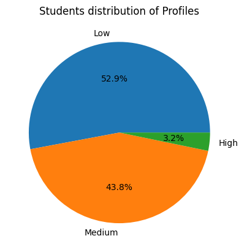

```python
profile_counts = data['Profile'].value_counts()
plt.pie(profile_counts, labels = profile_counts.index, autopct='%1.1f%%')
plt.title('Students distribution of Profiles')
plt.show()
```

### 5) Convert the Profile column into a Categorical Int

You have already created a column with three different values: 'Low', 'Medium', 'High'. These are Categorical values. But, it is important to notice that Neural Networks works better with numbers, since we apply mathematical operations to them.

Next you need to convert Profile values from Low, Medium and High, to 0, 1 and 2. IMPORTANT, the order does not matter, but make sure you always assign the same number to Low, same number to Medium and same number to High.

Make sure to use the fit_transform method from LabelEncoder.

De esta forma no porque ordena Medium = 2, Low = 1 y High = 0. Necesitamos ordenarlos en orden para que tengan sentido.

```python
# label_encoder = LabelEncoder()
# data['Profile'] = label_encoder.fit_transform(data['Profile'])
# data.head(10)
```

```python
data['Profile'].fillna('Low', inplace=True) # Rellenamos NAN's porque tiene.
```

```python
# Cambiamos temporalmente los valores para que LabelEncoder los ordene correctamente
data['Profile'] = data['Profile'].replace({'High': 'A', 'Medium': 'B', 'Low': 'C'})

label_encoder = LabelEncoder()
data['Profile'] = label_encoder.fit_transform(data['Profile'])
data['Profile'] = data['Profile'].replace({0: 2, 1: 1, 2: 0}) # Invertimos los valores para que se ajusten a 2 (High), 1 (Medium), 0 (Low)

data.head(10)
```

|  | StudentID | Age | Gender | Ethnicity | ParentalEducation | StudyTimeWeekly | Absences | Tutoring | ParentalSupport | Extracurricular | Sports | Music | Volunteering | GPA | GradeClass | Profile |
| --- | --- | --- | --- | --- | --- | --- | --- | --- | --- | --- | --- | --- | --- | --- | --- | --- |
| 0 | 1001 | 17 | 1 | 0 | 2 | 19.833723 | 7 | 1 | 2 | 0 | 0 | 1 | 0 | 2.929196 | 2.0 | 1 |
| 1 | 1002 | 18 | 0 | 0 | 1 | 15.408756 | 0 | 0 | 1 | 0 | 0 | 0 | 0 | 3.042915 | 1.0 | 1 |
| 2 | 1003 | 15 | 0 | 2 | 3 | 4.210570 | 26 | 0 | 2 | 0 | 0 | 0 | 0 | 0.112602 | 4.0 | 0 |
| 3 | 1004 | 17 | 1 | 0 | 3 | 10.028829 | 14 | 0 | 3 | 1 | 0 | 0 | 0 | 2.054218 | 3.0 | 1 |
| 4 | 1005 | 17 | 1 | 0 | 2 | 4.672495 | 17 | 1 | 3 | 0 | 0 | 0 | 0 | 1.288061 | 4.0 | 0 |
| 5 | 1006 | 18 | 0 | 0 | 1 | 8.191219 | 0 | 0 | 1 | 1 | 0 | 0 | 0 | 3.084184 | 1.0 | 1 |
| 6 | 1007 | 15 | 0 | 1 | 1 | 15.601680 | 10 | 0 | 3 | 0 | 1 | 0 | 0 | 2.748237 | 2.0 | 1 |
| 7 | 1008 | 15 | 1 | 1 | 4 | 15.424496 | 22 | 1 | 1 | 1 | 0 | 0 | 0 | 1.360143 | 4.0 | 0 |
| 8 | 1009 | 17 | 0 | 0 | 0 | 4.562008 | 1 | 0 | 2 | 0 | 1 | 0 | 1 | 2.896819 | 2.0 | 1 |
| 9 | 1010 | 16 | 1 | 0 | 1 | 18.444466 | 0 | 0 | 3 | 1 | 0 | 0 | 0 | 3.573474 | 0.0 | 2 |

# Experiment 1: A single Dense Hidden Layer

```python
X = data.drop(columns=['Profile'])
y = data['Profile']

X_train, X_test, y_train, y_test = train_test_split(X, y, test_size = 0.2, random_state = 42)

scaler = StandardScaler()
X_train = scaler.fit_transform(X_train)
X_test = scaler.transform(X_test)

model = Sequential()
model.add(Dense(64, input_shape = (X_train.shape[1],), activation = 'relu')) # Capa oculta con 64 unidades y funcion de activacion ReLu
model.add(Dense(3, activation = 'softmax'))  # Para mas de dos clases

model.compile(optimizer = 'adam', loss = 'sparse_categorical_crossentropy', metrics = ['accuracy'])

history = model.fit(X_train, y_train, epochs = 50, batch_size = 10, validation_split = 0.2, validation_data = (X_test, y_test))
```

```
192/192 ━━━━━━━━━━━━━━━━━━━━ 7s 9ms/step - accuracy: 0.6420 - loss: 0.8284 - val_accuracy: 0.9269 - val_loss: 0.3188
192/192 ━━━━━━━━━━━━━━━━━━━━ 2s 8ms/step - accuracy: 0.9357 - loss: 0.2914 - val_accuracy: 0.9374 - val_loss: 0.2204
192/192 ━━━━━━━━━━━━━━━━━━━━ 2s 7ms/step - accuracy: 0.9445 - loss: 0.2097 - val_accuracy: 0.9478 - val_loss: 0.1745
192/192 ━━━━━━━━━━━━━━━━━━━━ 1s 7ms/step - accuracy: 0.9567 - loss: 0.1537 - val_accuracy: 0.9520 - val_loss: 0.1467
192/192 ━━━━━━━━━━━━━━━━━━━━ 3s 9ms/step - accuracy: 0.9587 - loss: 0.1240 - val_accuracy: 0.9541 - val_loss: 0.1247
192/192 ━━━━━━━━━━━━━━━━━━━━ 2s 8ms/step - accuracy: 0.9656 - loss: 0.1097 - val_accuracy: 0.9562 - val_loss: 0.1125
192/192 ━━━━━━━━━━━━━━━━━━━━ 2s 3ms/step - accuracy: 0.9801 - loss: 0.0779 - val_accuracy: 0.9603 - val_loss: 0.1016
192/192 ━━━━━━━━━━━━━━━━━━━━ 1s 3ms/step - accuracy: 0.9816 - loss: 0.0728 - val_accuracy: 0.9687 - val_loss: 0.0922
192/192 ━━━━━━━━━━━━━━━━━━━━ 1s 3ms/step - accuracy: 0.9788 - loss: 0.0743 - val_accuracy: 0.9645 - val_loss: 0.0895
192/192 ━━━━━━━━━━━━━━━━━━━━ 1s 3ms/step - accuracy: 0.9850 - loss: 0.0564 - val_accuracy: 0.9770 - val_loss: 0.0814
192/192 ━━━━━━━━━━━━━━━━━━━━ 1s 3ms/step - accuracy: 0.9860 - loss: 0.0556 - val_accuracy: 0.9812 - val_loss: 0.0784
192/192 ━━━━━━━━━━━━━━━━━━━━ 1s 3ms/step - accuracy: 0.9916 - loss: 0.0396 - val_accuracy: 0.9833 - val_loss: 0.0715
192/192 ━━━━━━━━━━━━━━━━━━━━ 1s 3ms/step - accuracy: 0.9939 - loss: 0.0411 - val_accuracy: 0.9833 - val_loss: 0.0689
192/192 ━━━━━━━━━━━━━━━━━━━━ 1s 3ms/step - accuracy: 0.9934 - loss: 0.0343 - val_accuracy: 0.9833 - val_loss: 0.0697
192/192 ━━━━━━━━━━━━━━━━━━━━ 1s 3ms/step - accuracy: 0.9946 - loss: 0.0342 - val_accuracy: 0.9791 - val_loss: 0.0656
192/192 ━━━━━━━━━━━━━━━━━━━━ 1s 3ms/step - accuracy: 0.9944 - loss: 0.0282 - val_accuracy: 0.9791 - val_loss: 0.0677
192/192 ━━━━━━━━━━━━━━━━━━━━ 1s 4ms/step - accuracy: 0.9952 - loss: 0.0287 - val_accuracy: 0.9854 - val_loss: 0.0627
192/192 ━━━━━━━━━━━━━━━━━━━━ 1s 3ms/step - accuracy: 0.9936 - loss: 0.0275 - val_accuracy: 0.9833 - val_loss: 0.0686
192/192 ━━━━━━━━━━━━━━━━━━━━ 1s 4ms/step - accuracy: 0.9943 - loss: 0.0269 - val_accuracy: 0.9854 - val_loss: 0.0612
192/192 ━━━━━━━━━━━━━━━━━━━━ 1s 4ms/step - accuracy: 0.9974 - loss: 0.0198 - val_accuracy: 0.9854 - val_loss: 0.0593
192/192 ━━━━━━━━━━━━━━━━━━━━ 1s 5ms/step - accuracy: 0.9949 - loss: 0.0251 - val_accuracy: 0.9854 - val_loss: 0.0590
192/192 ━━━━━━━━━━━━━━━━━━━━ 1s 3ms/step - accuracy: 0.9971 - loss: 0.0223 - val_accuracy: 0.9833 - val_loss: 0.0601
192/192 ━━━━━━━━━━━━━━━━━━━━ 1s 3ms/step - accuracy: 0.9970 - loss: 0.0191 - val_accuracy: 0.9833 - val_loss: 0.0605
192/192 ━━━━━━━━━━━━━━━━━━━━ 1s 3ms/step - accuracy: 0.9975 - loss: 0.0178 - val_accuracy: 0.9854 - val_loss: 0.0589
192/192 ━━━━━━━━━━━━━━━━━━━━ 1s 3ms/step - accuracy: 0.9992 - loss: 0.0133 - val_accuracy: 0.9833 - val_loss: 0.0589
192/192 ━━━━━━━━━━━━━━━━━━━━ 1s 3ms/step - accuracy: 0.9975 - loss: 0.0144 - val_accuracy: 0.9812 - val_loss: 0.0640
192/192 ━━━━━━━━━━━━━━━━━━━━ 1s 3ms/step - accuracy: 0.9989 - loss: 0.0146 - val_accuracy: 0.9812 - val_loss: 0.0608
192/192 ━━━━━━━━━━━━━━━━━━━━ 1s 3ms/step - accuracy: 0.9987 - loss: 0.0131 - val_accuracy: 0.9791 - val_loss: 0.0590
192/192 ━━━━━━━━━━━━━━━━━━━━ 1s 3ms/step - accuracy: 0.9979 - loss: 0.0119 - val_accuracy: 0.9854 - val_loss: 0.0590
192/192 ━━━━━━━━━━━━━━━━━━━━ 1s 3ms/step - accuracy: 0.9998 - loss: 0.0127 - val_accuracy: 0.9854 - val_loss: 0.0577
192/192 ━━━━━━━━━━━━━━━━━━━━ 1s 2ms/step - accuracy: 0.9995 - loss: 0.0097 - val_accuracy: 0.9833 - val_loss: 0.0575
192/192 ━━━━━━━━━━━━━━━━━━━━ 1s 3ms/step - accuracy: 0.9956 - loss: 0.0126 - val_accuracy: 0.9791 - val_loss: 0.0594
192/192 ━━━━━━━━━━━━━━━━━━━━ 1s 3ms/step - accuracy: 0.9996 - loss: 0.0087 - val_accuracy: 0.9812 - val_loss: 0.0638
192/192 ━━━━━━━━━━━━━━━━━━━━ 1s 3ms/step - accuracy: 0.9995 - loss: 0.0077 - val_accuracy: 0.9854 - val_loss: 0.0574
192/192 ━━━━━━━━━━━━━━━━━━━━ 1s 3ms/step - accuracy: 0.9993 - loss: 0.0085 - val_accuracy: 0.9791 - val_loss: 0.0601
192/192 ━━━━━━━━━━━━━━━━━━━━ 1s 2ms/step - accuracy: 1.0000 - loss: 0.0063 - val_accuracy: 0.9791 - val_loss: 0.0609
192/192 ━━━━━━━━━━━━━━━━━━━━ 1s 2ms/step - accuracy: 0.9999 - loss: 0.0082 - val_accuracy: 0.9833 - val_loss: 0.0573
192/192 ━━━━━━━━━━━━━━━━━━━━ 1s 4ms/step - accuracy: 0.9998 - loss: 0.0053 - val_accuracy: 0.9875 - val_loss: 0.0544
192/192 ━━━━━━━━━━━━━━━━━━━━ 1s 4ms/step - accuracy: 1.0000 - loss: 0.0073 - val_accuracy: 0.9833 - val_loss: 0.0557
192/192 ━━━━━━━━━━━━━━━━━━━━ 1s 3ms/step - accuracy: 1.0000 - loss: 0.0072 - val_accuracy: 0.9833 - val_loss: 0.0599
192/192 ━━━━━━━━━━━━━━━━━━━━ 1s 3ms/step - accuracy: 1.0000 - loss: 0.0053 - val_accuracy: 0.9833 - val_loss: 0.0573
192/192 ━━━━━━━━━━━━━━━━━━━━ 1s 3ms/step - accuracy: 1.0000 - loss: 0.0048 - val_accuracy: 0.9812 - val_loss: 0.0608
192/192 ━━━━━━━━━━━━━━━━━━━━ 1s 3ms/step - accuracy: 1.0000 - loss: 0.0043 - val_accuracy: 0.9854 - val_loss: 0.0586
192/192 ━━━━━━━━━━━━━━━━━━━━ 1s 3ms/step - accuracy: 1.0000 - loss: 0.0042 - val_accuracy: 0.9812 - val_loss: 0.0606
192/192 ━━━━━━━━━━━━━━━━━━━━ 1s 3ms/step - accuracy: 1.0000 - loss: 0.0037 - val_accuracy: 0.9833 - val_loss: 0.0615
192/192 ━━━━━━━━━━━━━━━━━━━━ 1s 3ms/step - accuracy: 1.0000 - loss: 0.0032 - val_accuracy: 0.9812 - val_loss: 0.0642
192/192 ━━━━━━━━━━━━━━━━━━━━ 1s 4ms/step - accuracy: 1.0000 - loss: 0.0035 - val_accuracy: 0.9854 - val_loss: 0.0585
192/192 ━━━━━━━━━━━━━━━━━━━━ 2s 6ms/step - accuracy: 1.0000 - loss: 0.0035 - val_accuracy: 0.9854 - val_loss: 0.0557
192/192 ━━━━━━━━━━━━━━━━━━━━ 1s 5ms/step - accuracy: 1.0000 - loss: 0.0032 - val_accuracy: 0.9854 - val_loss: 0.0589
192/192 ━━━━━━━━━━━━━━━━━━━━ 1s 5ms/step - accuracy: 1.0000 - loss: 0.0024 - val_accuracy: 0.9833 - val_loss: 0.0596
```

```python
history_dict = history.history
accuracy = history_dict['accuracy']
val_accuracy = history_dict['val_accuracy']
loss = history_dict['loss']
val_loss = history_dict['val_loss']
epochs = range(1, len(accuracy) + 1)
```

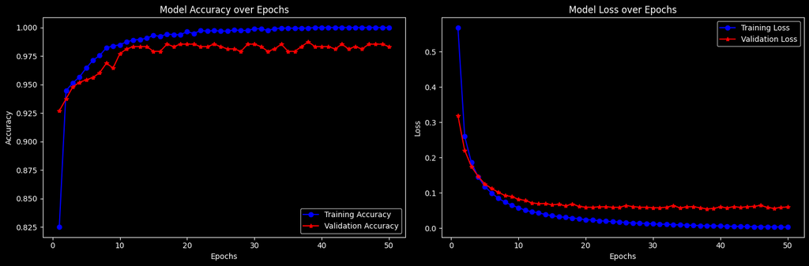

```python
plt.style.use('dark_background')

fig, (ax1, ax2) = plt.subplots(1, 2, figsize=(15, 5))
ax1.plot(epochs, accuracy, 'bo-', label='Training Accuracy')
ax1.plot(epochs, val_accuracy, 'r*-', label='Validation Accuracy')
ax1.set_title('Model Accuracy over Epochs')
ax1.set_xlabel('Epochs')
ax1.set_ylabel('Accuracy')
ax1.legend()

ax2.plot(epochs, loss, 'bo-', label='Training Loss')
ax2.plot(epochs, val_loss, 'r*-', label='Validation Loss')
ax2.set_title('Model Loss over Epochs')
ax2.set_xlabel('Epochs')
ax2.set_ylabel('Loss')
ax2.legend()

plt.tight_layout()
plt.show()
```

```python
predictions = model.predict(X_test)
predicted_classes = np.argmax(predictions, axis=1)
label_mapping = {0: 'Low', 1: 'Medium', 2: 'High'}

predicted_labels = [label_mapping[label] for label in predicted_classes]
actual_labels = [label_mapping[label] for label in y_test]

correct_predictions = sum(1 for i in range(len(predicted_labels)) if predicted_labels[i] == actual_labels[i])
total_predictions = len(predicted_labels)

# print("Predictions vs Actual Values:")
# for i in range(total_predictions):
#     print(f"Predicted: {predicted_labels[i]}, Actual: {actual_labels[i]}")

print(f"\nTotal correct predictions: {correct_predictions} / {total_predictions}")
```

```
15/15 ━━━━━━━━━━━━━━━━━━━━ 1s 20ms/step

Total correct predictions: 471 / 479
```

```python
from sklearn.metrics import accuracy_score, classification_report, confusion_matrix

accuracy = accuracy_score(y_test, predicted_classes)
print(f"\nModel Accuracy on Test Data: {accuracy:.2f}")
print("\nClassification Report:")
print(classification_report(y_test, predicted_classes, target_names=['Low', 'Medium', 'High']))
print("Confusion Matrix:")
print(confusion_matrix(y_test, predicted_classes))
```

```
Model Accuracy on Test Data: 0.98

Classification Report:
              precision    recall  f1-score   support

         Low       1.00      0.99      1.00       249
      Medium       0.97      1.00      0.98       214
        High       0.92      0.69      0.79        16

    accuracy                           0.98       479
   macro avg       0.96      0.89      0.92       479
weighted avg       0.98      0.98      0.98       479

Confusion Matrix:
[[247   2   0]
 [  0 213   1]
 [  0   5  11]]
```

## Experiment 2: A set of three Dense Hidden Layers

```python
X = data.drop(columns=['Profile'])
y = data['Profile']

X_train, X_test, y_train, y_test = train_test_split(X, y, test_size = 0.2, random_state = 42)

scaler = StandardScaler()
X_train = scaler.fit_transform(X_train)
X_test = scaler.transform(X_test)

model = Sequential()
model.add(Dense(128, input_shape=(X_train.shape[1],), activation = 'relu'))  # Primera capa oculta con 128 unidades y ReLU
model.add(Dense(64, activation = 'relu'))  # Segunda capa oculta con 64 unidades y ReLU
model.add(Dense(32, activation = 'relu'))  # Tercera capa oculta con 32 unidades y ReLU
model.add(Dense(3, activation = 'softmax')) # Tal vez sean demasiadas capas, siento que estamos Matando una mosca con una bazuca?

model.compile(optimizer = 'adam', loss = 'sparse_categorical_crossentropy', metrics = ['accuracy'])

history = model.fit(X_train, y_train, epochs = 50, batch_size = 10, validation_split = 0.2, validation_data = (X_test, y_test))
```

```
192/192 ━━━━━━━━━━━━━━━━━━━━ 7s 13ms/step - accuracy: 0.8339 - loss: 0.4980 - val_accuracy: 0.9415 - val_loss: 0.1475
192/192 ━━━━━━━━━━━━━━━━━━━━ 2s 8ms/step - accuracy: 0.9679 - loss: 0.0942 - val_accuracy: 0.9729 - val_loss: 0.0925
192/192 ━━━━━━━━━━━━━━━━━━━━ 3s 8ms/step - accuracy: 0.9785 - loss: 0.0750 - val_accuracy: 0.9562 - val_loss: 0.1046
192/192 ━━━━━━━━━━━━━━━━━━━━ 2s 11ms/step - accuracy: 0.9829 - loss: 0.0443 - val_accuracy: 0.9770 - val_loss: 0.0689
192/192 ━━━━━━━━━━━━━━━━━━━━ 3s 12ms/step - accuracy: 0.9900 - loss: 0.0432 - val_accuracy: 0.9729 - val_loss: 0.0937
192/192 ━━━━━━━━━━━━━━━━━━━━ 1s 3ms/step - accuracy: 0.9890 - loss: 0.0352 - val_accuracy: 0.9687 - val_loss: 0.0874
192/192 ━━━━━━━━━━━━━━━━━━━━ 1s 4ms/step - accuracy: 0.9980 - loss: 0.0194 - val_accuracy: 0.9708 - val_loss: 0.0909
192/192 ━━━━━━━━━━━━━━━━━━━━ 1s 3ms/step - accuracy: 0.9940 - loss: 0.0156 - val_accuracy: 0.9770 - val_loss: 0.0804
192/192 ━━━━━━━━━━━━━━━━━━━━ 1s 3ms/step - accuracy: 0.9971 - loss: 0.0099 - val_accuracy: 0.9770 - val_loss: 0.0834
192/192 ━━━━━━━━━━━━━━━━━━━━ 1s 3ms/step - accuracy: 0.9961 - loss: 0.0099 - val_accuracy: 0.9812 - val_loss: 0.0673
192/192 ━━━━━━━━━━━━━━━━━━━━ 1s 3ms/step - accuracy: 0.9967 - loss: 0.0106 - val_accuracy: 0.9770 - val_loss: 0.0819
192/192 ━━━━━━━━━━━━━━━━━━━━ 1s 3ms/step - accuracy: 0.9985 - loss: 0.0074 - val_accuracy: 0.9812 - val_loss: 0.0720
192/192 ━━━━━━━━━━━━━━━━━━━━ 1s 3ms/step - accuracy: 0.9992 - loss: 0.0056 - val_accuracy: 0.9770 - val_loss: 0.1167
192/192 ━━━━━━━━━━━━━━━━━━━━ 1s 4ms/step - accuracy: 0.9998 - loss: 0.0025 - val_accuracy: 0.9770 - val_loss: 0.1519
192/192 ━━━━━━━━━━━━━━━━━━━━ 1s 6ms/step - accuracy: 0.9946 - loss: 0.0137 - val_accuracy: 0.9833 - val_loss: 0.0853
192/192 ━━━━━━━━━━━━━━━━━━━━ 1s 6ms/step - accuracy: 0.9974 - loss: 0.0079 - val_accuracy: 0.9812 - val_loss: 0.0847
192/192 ━━━━━━━━━━━━━━━━━━━━ 2s 3ms/step - accuracy: 1.0000 - loss: 0.0020 - val_accuracy: 0.9812 - val_loss: 0.0928
192/192 ━━━━━━━━━━━━━━━━━━━━ 1s 3ms/step - accuracy: 1.0000 - loss: 8.3332e-04 - val_accuracy: 0.9812 - val_loss: 0.0945
192/192 ━━━━━━━━━━━━━━━━━━━━ 1s 3ms/step - accuracy: 1.0000 - loss: 4.9927e-04 - val_accuracy: 0.9812 - val_loss: 0.0943
192/192 ━━━━━━━━━━━━━━━━━━━━ 1s 3ms/step - accuracy: 1.0000 - loss: 4.8457e-04 - val_accuracy: 0.9812 - val_loss: 0.0944
192/192 ━━━━━━━━━━━━━━━━━━━━ 1s 4ms/step - accuracy: 1.0000 - loss: 2.8245e-04 - val_accuracy: 0.9812 - val_loss: 0.0949
192/192 ━━━━━━━━━━━━━━━━━━━━ 1s 3ms/step - accuracy: 1.0000 - loss: 2.2672e-04 - val_accuracy: 0.9812 - val_loss: 0.0957
192/192 ━━━━━━━━━━━━━━━━━━━━ 1s 3ms/step - accuracy: 1.0000 - loss: 1.8916e-04 - val_accuracy: 0.9812 - val_loss: 0.0990
192/192 ━━━━━━━━━━━━━━━━━━━━ 1s 3ms/step - accuracy: 1.0000 - loss: 2.0551e-04 - val_accuracy: 0.9812 - val_loss: 0.0972
192/192 ━━━━━━━━━━━━━━━━━━━━ 1s 3ms/step - accuracy: 1.0000 - loss: 1.7862e-04 - val_accuracy: 0.9812 - val_loss: 0.0985
192/192 ━━━━━━━━━━━━━━━━━━━━ 2s 5ms/step - accuracy: 1.0000 - loss: 1.4255e-04 - val_accuracy: 0.9812 - val_loss: 0.0992
192/192 ━━━━━━━━━━━━━━━━━━━━ 1s 6ms/step - accuracy: 1.0000 - loss: 9.9888e-05 - val_accuracy: 0.9812 - val_loss: 0.1021
192/192 ━━━━━━━━━━━━━━━━━━━━ 1s 5ms/step - accuracy: 1.0000 - loss: 1.2512e-04 - val_accuracy: 0.9812 - val_loss: 0.1019
192/192 ━━━━━━━━━━━━━━━━━━━━ 1s 3ms/step - accuracy: 1.0000 - loss: 9.1631e-05 - val_accuracy: 0.9812 - val_loss: 0.0991
192/192 ━━━━━━━━━━━━━━━━━━━━ 1s 3ms/step - accuracy: 1.0000 - loss: 9.9689e-05 - val_accuracy: 0.9812 - val_loss: 0.1055
192/192 ━━━━━━━━━━━━━━━━━━━━ 1s 3ms/step - accuracy: 1.0000 - loss: 6.6464e-05 - val_accuracy: 0.9812 - val_loss: 0.1112
192/192 ━━━━━━━━━━━━━━━━━━━━ 1s 3ms/step - accuracy: 1.0000 - loss: 7.8280e-05 - val_accuracy: 0.9812 - val_loss: 0.1067
192/192 ━━━━━━━━━━━━━━━━━━━━ 1s 3ms/step - accuracy: 1.0000 - loss: 4.7125e-05 - val_accuracy: 0.9833 - val_loss: 0.1067
192/192 ━━━━━━━━━━━━━━━━━━━━ 1s 6ms/step - accuracy: 1.0000 - loss: 5.4179e-05 - val_accuracy: 0.9812 - val_loss: 0.1104
192/192 ━━━━━━━━━━━━━━━━━━━━ 1s 3ms/step - accuracy: 1.0000 - loss: 3.6633e-05 - val_accuracy: 0.9812 - val_loss: 0.1048
192/192 ━━━━━━━━━━━━━━━━━━━━ 1s 3ms/step - accuracy: 1.0000 - loss: 4.5846e-05 - val_accuracy: 0.9812 - val_loss: 0.1085
192/192 ━━━━━━━━━━━━━━━━━━━━ 1s 3ms/step - accuracy: 1.0000 - loss: 2.4047e-05 - val_accuracy: 0.9812 - val_loss: 0.1106
192/192 ━━━━━━━━━━━━━━━━━━━━ 1s 4ms/step - accuracy: 1.0000 - loss: 3.8609e-05 - val_accuracy: 0.9812 - val_loss: 0.1115
192/192 ━━━━━━━━━━━━━━━━━━━━ 2s 7ms/step - accuracy: 1.0000 - loss: 2.5638e-05 - val_accuracy: 0.9812 - val_loss: 0.1141
192/192 ━━━━━━━━━━━━━━━━━━━━ 2s 6ms/step - accuracy: 1.0000 - loss: 2.7133e-05 - val_accuracy: 0.9812 - val_loss: 0.1117
192/192 ━━━━━━━━━━━━━━━━━━━━ 1s 4ms/step - accuracy: 1.0000 - loss: 2.4949e-05 - val_accuracy: 0.9812 - val_loss: 0.1138
192/192 ━━━━━━━━━━━━━━━━━━━━ 2s 5ms/step - accuracy: 1.0000 - loss: 2.3351e-05 - val_accuracy: 0.9812 - val_loss: 0.1121
192/192 ━━━━━━━━━━━━━━━━━━━━ 1s 4ms/step - accuracy: 1.0000 - loss: 1.6413e-05 - val_accuracy: 0.9812 - val_loss: 0.1166
192/192 ━━━━━━━━━━━━━━━━━━━━ 1s 3ms/step - accuracy: 1.0000 - loss: 1.5387e-05 - val_accuracy: 0.9812 - val_loss: 0.1144
192/192 ━━━━━━━━━━━━━━━━━━━━ 1s 3ms/step - accuracy: 1.0000 - loss: 1.7651e-05 - val_accuracy: 0.9812 - val_loss: 0.1183
192/192 ━━━━━━━━━━━━━━━━━━━━ 1s 4ms/step - accuracy: 1.0000 - loss: 1.2838e-05 - val_accuracy: 0.9812 - val_loss: 0.1196
192/192 ━━━━━━━━━━━━━━━━━━━━ 1s 3ms/step - accuracy: 1.0000 - loss: 1.2934e-05 - val_accuracy: 0.9812 - val_loss: 0.1210
192/192 ━━━━━━━━━━━━━━━━━━━━ 1s 3ms/step - accuracy: 1.0000 - loss: 8.4241e-06 - val_accuracy: 0.9812 - val_loss: 0.1200
192/192 ━━━━━━━━━━━━━━━━━━━━ 1s 6ms/step - accuracy: 1.0000 - loss: 9.1584e-06 - val_accuracy: 0.9812 - val_loss: 0.1190
192/192 ━━━━━━━━━━━━━━━━━━━━ 1s 5ms/step - accuracy: 1.0000 - loss: 8.8016e-06 - val_accuracy: 0.9812 - val_loss: 0.1163
```

```python
history_dict = history.history
accuracy = history_dict['accuracy']
val_accuracy = history_dict['val_accuracy']
loss = history_dict['loss']
val_loss = history_dict['val_loss']
epochs = range(1, len(accuracy) + 1)
```

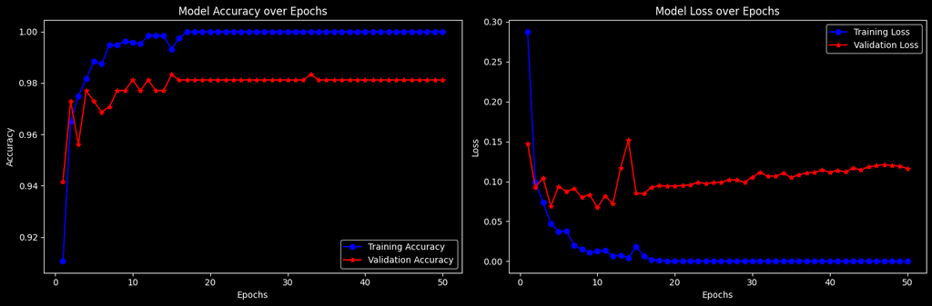

```python
plt.style.use('dark_background')

fig, (ax1, ax2) = plt.subplots(1, 2, figsize=(15, 5))
ax1.plot(epochs, accuracy, 'bo-', label='Training Accuracy')
ax1.plot(epochs, val_accuracy, 'r*-', label='Validation Accuracy')
ax1.set_title('Model Accuracy over Epochs')
ax1.set_xlabel('Epochs')
ax1.set_ylabel('Accuracy')
ax1.legend()

ax2.plot(epochs, loss, 'bo-', label='Training Loss')
ax2.plot(epochs, val_loss, 'r*-', label='Validation Loss')
ax2.set_title('Model Loss over Epochs')
ax2.set_xlabel('Epochs')
ax2.set_ylabel('Loss')
ax2.legend()

plt.tight_layout()
plt.show()
```

```python
predictions = model.predict(X_test)
predicted_classes = np.argmax(predictions, axis=1)
label_mapping = {0: 'Low', 1: 'Medium', 2: 'High'}

predicted_labels = [label_mapping[label] for label in predicted_classes]
actual_labels = [label_mapping[label] for label in y_test]

correct_predictions = sum(1 for i in range(len(predicted_labels)) if predicted_labels[i] == actual_labels[i])
total_predictions = len(predicted_labels)

# print("Predictions vs Actual Values:")
# for i in range(total_predictions):
#     print(f"Predicted: {predicted_labels[i]}, Actual: {actual_labels[i]}")

print(f"\nTotal correct predictions: {correct_predictions} / {total_predictions}")
```

```
15/15 ━━━━━━━━━━━━━━━━━━━━ 0s 10ms/step

Total correct predictions: 470 / 479
```

```python
from sklearn.metrics import accuracy_score, classification_report, confusion_matrix

accuracy = accuracy_score(y_test, predicted_classes)
print(f"\nModel Accuracy on Test Data: {accuracy:.2f}")
print("\nClassification Report:")
print(classification_report(y_test, predicted_classes, target_names=['Low', 'Medium', 'High']))
print("Confusion Matrix:")
print(confusion_matrix(y_test, predicted_classes))
```

```
Model Accuracy on Test Data: 0.98

Classification Report:
              precision    recall  f1-score   support

         Low       1.00      0.99      0.99       249
      Medium       0.97      0.99      0.98       214
        High       0.92      0.69      0.79        16

    accuracy                           0.98       479
   macro avg       0.96      0.89      0.92       479
weighted avg       0.98      0.98      0.98       479

Confusion Matrix:
[[247   2   0]
 [  1 212   1]
 [  0   5  11]]
```

## Experiment 3: Add a dropout layer after each Dense Hidden Layer

```python
X = data.drop(columns=['Profile'])
y = data['Profile']

X_train, X_test, y_train, y_test = train_test_split(X, y, test_size = 0.2, random_state = 42)

scaler = StandardScaler()
X_train = scaler.fit_transform(X_train)
X_test = scaler.transform(X_test)

model = Sequential()
model.add(Dense(128, input_shape=(X_train.shape[1],), activation = 'relu'))  # Primera capa oculta con 128 unidades y ReLU
model.add(Dropout(0.5))                                                      # Capa Dropout con 50% de desactivación
model.add(Dense(64, activation = 'relu'))                                    # Segunda capa oculta con 64 unidades y ReLU
model.add(Dropout(0.5))                                                      # Capa Dropout con 50% de desactivación
model.add(Dense(32, activation = 'relu'))                                    # Tercera capa oculta con 32 unidades y ReLU
model.add(Dropout(0.5))                                                      # Capa Dropout con 50% de desactivación
model.add(Dense(3, activation = 'softmax'))                                  # Capa de salida para clasificación multiclase

model.compile(optimizer = 'adam', loss = 'sparse_categorical_crossentropy', metrics = ['accuracy'])

history = model.fit(X_train, y_train, epochs = 50, batch_size = 10, validation_split = 0.2, validation_data = (X_test, y_test))
```

```
192/192 ━━━━━━━━━━━━━━━━━━━━ 3s 5ms/step - accuracy: 0.6180 - loss: 0.8518 - val_accuracy: 0.9374 - val_loss: 0.2863
192/192 ━━━━━━━━━━━━━━━━━━━━ 1s 3ms/step - accuracy: 0.8758 - loss: 0.4162 - val_accuracy: 0.9415 - val_loss: 0.2293
192/192 ━━━━━━━━━━━━━━━━━━━━ 1s 4ms/step - accuracy: 0.9085 - loss: 0.3039 - val_accuracy: 0.9499 - val_loss: 0.1869
192/192 ━━━━━━━━━━━━━━━━━━━━ 1s 3ms/step - accuracy: 0.9215 - loss: 0.2616 - val_accuracy: 0.9436 - val_loss: 0.1769
192/192 ━━━━━━━━━━━━━━━━━━━━ 1s 4ms/step - accuracy: 0.9318 - loss: 0.2804 - val_accuracy: 0.9499 - val_loss: 0.1583
192/192 ━━━━━━━━━━━━━━━━━━━━ 1s 4ms/step - accuracy: 0.9484 - loss: 0.1957 - val_accuracy: 0.9499 - val_loss: 0.1514
192/192 ━━━━━━━━━━━━━━━━━━━━ 1s 5ms/step - accuracy: 0.9551 - loss: 0.1607 - val_accuracy: 0.9541 - val_loss: 0.1282
192/192 ━━━━━━━━━━━━━━━━━━━━ 1s 4ms/step - accuracy: 0.9470 - loss: 0.1840 - val_accuracy: 0.9562 - val_loss: 0.1176
192/192 ━━━━━━━━━━━━━━━━━━━━ 2s 6ms/step - accuracy: 0.9527 - loss: 0.1487 - val_accuracy: 0.9562 - val_loss: 0.1190
192/192 ━━━━━━━━━━━━━━━━━━━━ 1s 6ms/step - accuracy: 0.9617 - loss: 0.1338 - val_accuracy: 0.9562 - val_loss: 0.1092
192/192 ━━━━━━━━━━━━━━━━━━━━ 1s 5ms/step - accuracy: 0.9452 - loss: 0.1666 - val_accuracy: 0.9582 - val_loss: 0.1045
192/192 ━━━━━━━━━━━━━━━━━━━━ 2s 8ms/step - accuracy: 0.9528 - loss: 0.1366 - val_accuracy: 0.9562 - val_loss: 0.0985
192/192 ━━━━━━━━━━━━━━━━━━━━ 3s 9ms/step - accuracy: 0.9552 - loss: 0.1429 - val_accuracy: 0.9520 - val_loss: 0.1024
192/192 ━━━━━━━━━━━━━━━━━━━━ 2s 7ms/step - accuracy: 0.9650 - loss: 0.1059 - val_accuracy: 0.9562 - val_loss: 0.0945
192/192 ━━━━━━━━━━━━━━━━━━━━ 2s 8ms/step - accuracy: 0.9663 - loss: 0.0962 - val_accuracy: 0.9624 - val_loss: 0.0870
192/192 ━━━━━━━━━━━━━━━━━━━━ 2s 5ms/step - accuracy: 0.9669 - loss: 0.0960 - val_accuracy: 0.9624 - val_loss: 0.0786
192/192 ━━━━━━━━━━━━━━━━━━━━ 1s 5ms/step - accuracy: 0.9652 - loss: 0.0846 - val_accuracy: 0.9624 - val_loss: 0.0771
192/192 ━━━━━━━━━━━━━━━━━━━━ 1s 5ms/step - accuracy: 0.9683 - loss: 0.0832 - val_accuracy: 0.9562 - val_loss: 0.0853
192/192 ━━━━━━━━━━━━━━━━━━━━ 1s 4ms/step - accuracy: 0.9675 - loss: 0.0893 - val_accuracy: 0.9749 - val_loss: 0.0845
192/192 ━━━━━━━━━━━━━━━━━━━━ 1s 4ms/step - accuracy: 0.9643 - loss: 0.0998 - val_accuracy: 0.9770 - val_loss: 0.0768
192/192 ━━━━━━━━━━━━━━━━━━━━ 1s 4ms/step - accuracy: 0.9683 - loss: 0.0827 - val_accuracy: 0.9645 - val_loss: 0.0790
192/192 ━━━━━━━━━━━━━━━━━━━━ 1s 4ms/step - accuracy: 0.9709 - loss: 0.0792 - val_accuracy: 0.9562 - val_loss: 0.1061
192/192 ━━━━━━━━━━━━━━━━━━━━ 1s 4ms/step - accuracy: 0.9697 - loss: 0.0955 - val_accuracy: 0.9687 - val_loss: 0.0869
192/192 ━━━━━━━━━━━━━━━━━━━━ 1s 3ms/step - accuracy: 0.9666 - loss: 0.0892 - val_accuracy: 0.9603 - val_loss: 0.0831
192/192 ━━━━━━━━━━━━━━━━━━━━ 1s 3ms/step - accuracy: 0.9695 - loss: 0.0870 - val_accuracy: 0.9749 - val_loss: 0.0788
192/192 ━━━━━━━━━━━━━━━━━━━━ 2s 5ms/step - accuracy: 0.9678 - loss: 0.0668 - val_accuracy: 0.9603 - val_loss: 0.0883
192/192 ━━━━━━━━━━━━━━━━━━━━ 1s 3ms/step - accuracy: 0.9689 - loss: 0.0656 - val_accuracy: 0.9687 - val_loss: 0.0889
192/192 ━━━━━━━━━━━━━━━━━━━━ 2s 5ms/step - accuracy: 0.9684 - loss: 0.0620 - val_accuracy: 0.9687 - val_loss: 0.0908
192/192 ━━━━━━━━━━━━━━━━━━━━ 1s 6ms/step - accuracy: 0.9766 - loss: 0.0558 - val_accuracy: 0.9708 - val_loss: 0.0830
192/192 ━━━━━━━━━━━━━━━━━━━━ 2s 11ms/step - accuracy: 0.9767 - loss: 0.0638 - val_accuracy: 0.9749 - val_loss: 0.0907
192/192 ━━━━━━━━━━━━━━━━━━━━ 1s 5ms/step - accuracy: 0.9786 - loss: 0.0434 - val_accuracy: 0.9791 - val_loss: 0.0727
192/192 ━━━━━━━━━━━━━━━━━━━━ 1s 5ms/step - accuracy: 0.9762 - loss: 0.0560 - val_accuracy: 0.9708 - val_loss: 0.0794
192/192 ━━━━━━━━━━━━━━━━━━━━ 1s 7ms/step - accuracy: 0.9744 - loss: 0.0665 - val_accuracy: 0.9812 - val_loss: 0.0732
192/192 ━━━━━━━━━━━━━━━━━━━━ 1s 5ms/step - accuracy: 0.9829 - loss: 0.0589 - val_accuracy: 0.9812 - val_loss: 0.0689
192/192 ━━━━━━━━━━━━━━━━━━━━ 1s 4ms/step - accuracy: 0.9785 - loss: 0.0494 - val_accuracy: 0.9749 - val_loss: 0.0655
192/192 ━━━━━━━━━━━━━━━━━━━━ 1s 3ms/step - accuracy: 0.9792 - loss: 0.0545 - val_accuracy: 0.9791 - val_loss: 0.0688
192/192 ━━━━━━━━━━━━━━━━━━━━ 2s 5ms/step - accuracy: 0.9735 - loss: 0.0643 - val_accuracy: 0.9812 - val_loss: 0.0709
192/192 ━━━━━━━━━━━━━━━━━━━━ 1s 6ms/step - accuracy: 0.9826 - loss: 0.0426 - val_accuracy: 0.9812 - val_loss: 0.0718
192/192 ━━━━━━━━━━━━━━━━━━━━ 1s 7ms/step - accuracy: 0.9766 - loss: 0.0600 - val_accuracy: 0.9749 - val_loss: 0.0862
192/192 ━━━━━━━━━━━━━━━━━━━━ 1s 6ms/step - accuracy: 0.9886 - loss: 0.0329 - val_accuracy: 0.9791 - val_loss: 0.0679
192/192 ━━━━━━━━━━━━━━━━━━━━ 2s 5ms/step - accuracy: 0.9853 - loss: 0.0439 - val_accuracy: 0.9812 - val_loss: 0.0707
192/192 ━━━━━━━━━━━━━━━━━━━━ 1s 4ms/step - accuracy: 0.9858 - loss: 0.0323 - val_accuracy: 0.9812 - val_loss: 0.0756
192/192 ━━━━━━━━━━━━━━━━━━━━ 1s 4ms/step - accuracy: 0.9903 - loss: 0.0299 - val_accuracy: 0.9833 - val_loss: 0.0754
192/192 ━━━━━━━━━━━━━━━━━━━━ 2s 5ms/step - accuracy: 0.9865 - loss: 0.0339 - val_accuracy: 0.9833 - val_loss: 0.0691
192/192 ━━━━━━━━━━━━━━━━━━━━ 1s 4ms/step - accuracy: 0.9851 - loss: 0.0428 - val_accuracy: 0.9812 - val_loss: 0.0665
192/192 ━━━━━━━━━━━━━━━━━━━━ 1s 3ms/step - accuracy: 0.9875 - loss: 0.0358 - val_accuracy: 0.9812 - val_loss: 0.0737
192/192 ━━━━━━━━━━━━━━━━━━━━ 1s 3ms/step - accuracy: 0.9809 - loss: 0.0449 - val_accuracy: 0.9812 - val_loss: 0.0607
192/192 ━━━━━━━━━━━━━━━━━━━━ 1s 3ms/step - accuracy: 0.9878 - loss: 0.0354 - val_accuracy: 0.9875 - val_loss: 0.0578
192/192 ━━━━━━━━━━━━━━━━━━━━ 2s 5ms/step - accuracy: 0.9829 - loss: 0.0428 - val_accuracy: 0.9833 - val_loss: 0.0567
192/192 ━━━━━━━━━━━━━━━━━━━━ 1s 5ms/step - accuracy: 0.9854 - loss: 0.0387 - val_accuracy: 0.9791 - val_loss: 0.0598
```

```python
history_dict = history.history
accuracy = history_dict['accuracy']
val_accuracy = history_dict['val_accuracy']
loss = history_dict['loss']
val_loss = history_dict['val_loss']
epochs = range(1, len(accuracy) + 1)
```

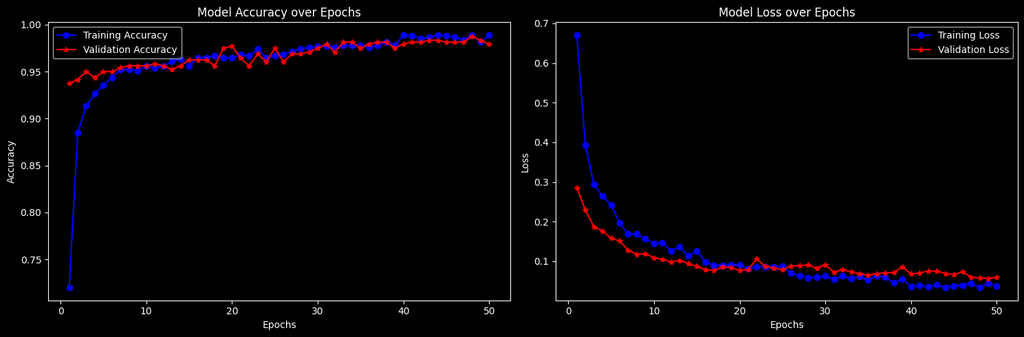

```python
plt.style.use('dark_background')

fig, (ax1, ax2) = plt.subplots(1, 2, figsize=(15, 5))
ax1.plot(epochs, accuracy, 'bo-', label='Training Accuracy')
ax1.plot(epochs, val_accuracy, 'r*-', label='Validation Accuracy')
ax1.set_title('Model Accuracy over Epochs')
ax1.set_xlabel('Epochs')
ax1.set_ylabel('Accuracy')
ax1.legend()

ax2.plot(epochs, loss, 'bo-', label='Training Loss')
ax2.plot(epochs, val_loss, 'r*-', label='Validation Loss')
ax2.set_title('Model Loss over Epochs')
ax2.set_xlabel('Epochs')
ax2.set_ylabel('Loss')
ax2.legend()

plt.tight_layout()
plt.show()
```

```python
predictions = model.predict(X_test)
predicted_classes = np.argmax(predictions, axis=1)
label_mapping = {0: 'Low', 1: 'Medium', 2: 'High'}

predicted_labels = [label_mapping[label] for label in predicted_classes]
actual_labels = [label_mapping[label] for label in y_test]

correct_predictions = sum(1 for i in range(len(predicted_labels)) if predicted_labels[i] == actual_labels[i])
total_predictions = len(predicted_labels)

# print("Predictions vs Actual Values:")
# for i in range(total_predictions):
#     print(f"Predicted: {predicted_labels[i]}, Actual: {actual_labels[i]}")

print(f"\nTotal correct predictions: {correct_predictions} / {total_predictions}")
```

```
15/15 ━━━━━━━━━━━━━━━━━━━━ 0s 9ms/step

Total correct predictions: 469 / 479
```

```python
from sklearn.metrics import accuracy_score, classification_report, confusion_matrix

accuracy = accuracy_score(y_test, predicted_classes)
print(f"\nModel Accuracy on Test Data: {accuracy:.2f}")
print("\nClassification Report:")
print(classification_report(y_test, predicted_classes, target_names=['Low', 'Medium', 'High']))
print("Confusion Matrix:")
print(confusion_matrix(y_test, predicted_classes))
```

```
Model Accuracy on Test Data: 0.98

Classification Report:
              precision    recall  f1-score   support

         Low       1.00      0.99      0.99       249
      Medium       0.97      0.99      0.98       214
        High       0.85      0.69      0.76        16

    accuracy                           0.98       479
   macro avg       0.94      0.89      0.91       479
weighted avg       0.98      0.98      0.98       479

Confusion Matrix:
[[247   2   0]
 [  1 211   2]
 [  0   5  11]]
```

## Experiment 4: Add a Batch Normalization Layer BEFORE each Dropout Layer.

Tener cuidado aquí, ya que si las añadimos después nos da un rendimiento peor.

```python
from tensorflow.keras.layers import BatchNormalization

X = data.drop(columns=['Profile'])
y = data['Profile']

X_train, X_test, y_train, y_test = train_test_split(X, y, test_size = 0.2, random_state = 42)

scaler = StandardScaler()
X_train = scaler.fit_transform(X_train)
X_test = scaler.transform(X_test)

model = Sequential()
model.add(Dense(128, input_shape=(X_train.shape[1],), activation = 'relu'))
model.add(BatchNormalization())
model.add(Dropout(0.5))

model.add(Dense(64, activation = 'relu'))
model.add(BatchNormalization())
model.add(Dropout(0.5))

model.add(Dense(32, activation = 'relu'))
model.add(BatchNormalization())
model.add(Dropout(0.5))

model.add(Dense(3, activation = 'softmax'))

model.compile(optimizer = 'adam', loss = 'sparse_categorical_crossentropy', metrics = ['accuracy'])

history = model.fit(X_train, y_train, epochs = 50, batch_size = 10, validation_split = 0.2, validation_data = (X_test, y_test))
```

```
192/192 ━━━━━━━━━━━━━━━━━━━━ 4s 5ms/step - accuracy: 0.4367 - loss: 1.4128 - val_accuracy: 0.8079 - val_loss: 0.5618
192/192 ━━━━━━━━━━━━━━━━━━━━ 1s 4ms/step - accuracy: 0.6875 - loss: 0.7240 - val_accuracy: 0.9081 - val_loss: 0.3106
192/192 ━━━━━━━━━━━━━━━━━━━━ 1s 4ms/step - accuracy: 0.8342 - loss: 0.4589 - val_accuracy: 0.9332 - val_loss: 0.2460
192/192 ━━━━━━━━━━━━━━━━━━━━ 1s 5ms/step - accuracy: 0.8288 - loss: 0.4446 - val_accuracy: 0.9395 - val_loss: 0.2167
192/192 ━━━━━━━━━━━━━━━━━━━━ 1s 4ms/step - accuracy: 0.8229 - loss: 0.4637 - val_accuracy: 0.9353 - val_loss: 0.2054
192/192 ━━━━━━━━━━━━━━━━━━━━ 1s 5ms/step - accuracy: 0.8371 - loss: 0.4257 - val_accuracy: 0.9541 - val_loss: 0.1814
192/192 ━━━━━━━━━━━━━━━━━━━━ 1s 6ms/step - accuracy: 0.8650 - loss: 0.3924 - val_accuracy: 0.9478 - val_loss: 0.1795
192/192 ━━━━━━━━━━━━━━━━━━━━ 2s 8ms/step - accuracy: 0.8826 - loss: 0.3254 - val_accuracy: 0.9603 - val_loss: 0.1614
192/192 ━━━━━━━━━━━━━━━━━━━━ 1s 6ms/step - accuracy: 0.8686 - loss: 0.3353 - val_accuracy: 0.9541 - val_loss: 0.1486
192/192 ━━━━━━━━━━━━━━━━━━━━ 1s 4ms/step - accuracy: 0.8695 - loss: 0.3211 - val_accuracy: 0.9582 - val_loss: 0.1384
192/192 ━━━━━━━━━━━━━━━━━━━━ 1s 5ms/step - accuracy: 0.8842 - loss: 0.3131 - val_accuracy: 0.9645 - val_loss: 0.1316
192/192 ━━━━━━━━━━━━━━━━━━━━ 1s 4ms/step - accuracy: 0.9101 - loss: 0.2555 - val_accuracy: 0.9645 - val_loss: 0.1238
192/192 ━━━━━━━━━━━━━━━━━━━━ 1s 5ms/step - accuracy: 0.9044 - loss: 0.2690 - val_accuracy: 0.9624 - val_loss: 0.1172
192/192 ━━━━━━━━━━━━━━━━━━━━ 1s 4ms/step - accuracy: 0.9103 - loss: 0.2660 - val_accuracy: 0.9645 - val_loss: 0.1076
192/192 ━━━━━━━━━━━━━━━━━━━━ 1s 4ms/step - accuracy: 0.9104 - loss: 0.2502 - val_accuracy: 0.9603 - val_loss: 0.0990
192/192 ━━━━━━━━━━━━━━━━━━━━ 1s 4ms/step - accuracy: 0.9000 - loss: 0.2833 - val_accuracy: 0.9624 - val_loss: 0.0973
192/192 ━━━━━━━━━━━━━━━━━━━━ 1s 4ms/step - accuracy: 0.9236 - loss: 0.2237 - val_accuracy: 0.9624 - val_loss: 0.0953
192/192 ━━━━━━━━━━━━━━━━━━━━ 1s 5ms/step - accuracy: 0.8981 - loss: 0.3195 - val_accuracy: 0.9645 - val_loss: 0.1019
192/192 ━━━━━━━━━━━━━━━━━━━━ 1s 6ms/step - accuracy: 0.9265 - loss: 0.2348 - val_accuracy: 0.9582 - val_loss: 0.0976
192/192 ━━━━━━━━━━━━━━━━━━━━ 1s 7ms/step - accuracy: 0.9264 - loss: 0.2252 - val_accuracy: 0.9666 - val_loss: 0.0905
192/192 ━━━━━━━━━━━━━━━━━━━━ 2s 4ms/step - accuracy: 0.9261 - loss: 0.1954 - val_accuracy: 0.9708 - val_loss: 0.0835
192/192 ━━━━━━━━━━━━━━━━━━━━ 1s 5ms/step - accuracy: 0.9292 - loss: 0.2051 - val_accuracy: 0.9708 - val_loss: 0.0818
192/192 ━━━━━━━━━━━━━━━━━━━━ 1s 5ms/step - accuracy: 0.9245 - loss: 0.2149 - val_accuracy: 0.9645 - val_loss: 0.0795
192/192 ━━━━━━━━━━━━━━━━━━━━ 1s 4ms/step - accuracy: 0.9233 - loss: 0.2020 - val_accuracy: 0.9666 - val_loss: 0.0770
192/192 ━━━━━━━━━━━━━━━━━━━━ 1s 4ms/step - accuracy: 0.9297 - loss: 0.2099 - val_accuracy: 0.9708 - val_loss: 0.0777
192/192 ━━━━━━━━━━━━━━━━━━━━ 1s 4ms/step - accuracy: 0.9285 - loss: 0.2052 - val_accuracy: 0.9708 - val_loss: 0.0784
192/192 ━━━━━━━━━━━━━━━━━━━━ 1s 4ms/step - accuracy: 0.9226 - loss: 0.2180 - val_accuracy: 0.9687 - val_loss: 0.0744
192/192 ━━━━━━━━━━━━━━━━━━━━ 1s 4ms/step - accuracy: 0.9347 - loss: 0.1914 - val_accuracy: 0.9854 - val_loss: 0.0734
192/192 ━━━━━━━━━━━━━━━━━━━━ 1s 4ms/step - accuracy: 0.9205 - loss: 0.2307 - val_accuracy: 0.9749 - val_loss: 0.0786
192/192 ━━━━━━━━━━━━━━━━━━━━ 2s 6ms/step - accuracy: 0.9328 - loss: 0.1927 - val_accuracy: 0.9729 - val_loss: 0.0740
192/192 ━━━━━━━━━━━━━━━━━━━━ 1s 7ms/step - accuracy: 0.9297 - loss: 0.1977 - val_accuracy: 0.9854 - val_loss: 0.0759
192/192 ━━━━━━━━━━━━━━━━━━━━ 1s 6ms/step - accuracy: 0.9291 - loss: 0.1856 - val_accuracy: 0.9791 - val_loss: 0.0707
192/192 ━━━━━━━━━━━━━━━━━━━━ 1s 4ms/step - accuracy: 0.9271 - loss: 0.1964 - val_accuracy: 0.9896 - val_loss: 0.0725
192/192 ━━━━━━━━━━━━━━━━━━━━ 1s 4ms/step - accuracy: 0.9321 - loss: 0.1918 - val_accuracy: 0.9770 - val_loss: 0.0712
192/192 ━━━━━━━━━━━━━━━━━━━━ 1s 5ms/step - accuracy: 0.9357 - loss: 0.1679 - val_accuracy: 0.9854 - val_loss: 0.0673
192/192 ━━━━━━━━━━━━━━━━━━━━ 1s 4ms/step - accuracy: 0.9344 - loss: 0.1826 - val_accuracy: 0.9896 - val_loss: 0.0667
192/192 ━━━━━━━━━━━━━━━━━━━━ 1s 4ms/step - accuracy: 0.9281 - loss: 0.1899 - val_accuracy: 0.9770 - val_loss: 0.0679
192/192 ━━━━━━━━━━━━━━━━━━━━ 1s 4ms/step - accuracy: 0.9290 - loss: 0.2068 - val_accuracy: 0.9791 - val_loss: 0.0633
192/192 ━━━━━━━━━━━━━━━━━━━━ 1s 5ms/step - accuracy: 0.9254 - loss: 0.2109 - val_accuracy: 0.9854 - val_loss: 0.0657
192/192 ━━━━━━━━━━━━━━━━━━━━ 1s 4ms/step - accuracy: 0.9352 - loss: 0.1976 - val_accuracy: 0.9812 - val_loss: 0.0622
192/192 ━━━━━━━━━━━━━━━━━━━━ 1s 4ms/step - accuracy: 0.9389 - loss: 0.1989 - val_accuracy: 0.9791 - val_loss: 0.0645
192/192 ━━━━━━━━━━━━━━━━━━━━ 1s 6ms/step - accuracy: 0.9433 - loss: 0.1567 - val_accuracy: 0.9812 - val_loss: 0.0652
192/192 ━━━━━━━━━━━━━━━━━━━━ 1s 6ms/step - accuracy: 0.9423 - loss: 0.1612 - val_accuracy: 0.9812 - val_loss: 0.0663
192/192 ━━━━━━━━━━━━━━━━━━━━ 1s 6ms/step - accuracy: 0.9464 - loss: 0.1452 - val_accuracy: 0.9791 - val_loss: 0.0657
192/192 ━━━━━━━━━━━━━━━━━━━━ 1s 5ms/step - accuracy: 0.9489 - loss: 0.1489 - val_accuracy: 0.9854 - val_loss: 0.0615
192/192 ━━━━━━━━━━━━━━━━━━━━ 1s 4ms/step - accuracy: 0.9298 - loss: 0.2247 - val_accuracy: 0.9812 - val_loss: 0.0620
192/192 ━━━━━━━━━━━━━━━━━━━━ 1s 4ms/step - accuracy: 0.9427 - loss: 0.1473 - val_accuracy: 0.9812 - val_loss: 0.0638
192/192 ━━━━━━━━━━━━━━━━━━━━ 1s 4ms/step - accuracy: 0.9338 - loss: 0.1767 - val_accuracy: 0.9812 - val_loss: 0.0600
192/192 ━━━━━━━━━━━━━━━━━━━━ 1s 7ms/step - accuracy: 0.9435 - loss: 0.1819 - val_accuracy: 0.9833 - val_loss: 0.0575
192/192 ━━━━━━━━━━━━━━━━━━━━ 2s 4ms/step - accuracy: 0.9537 - loss: 0.1444 - val_accuracy: 0.9854 - val_loss: 0.0600
```

```python
history_dict = history.history
accuracy = history_dict['accuracy']
val_accuracy = history_dict['val_accuracy']
loss = history_dict['loss']
val_loss = history_dict['val_loss']
epochs = range(1, len(accuracy) + 1)
```

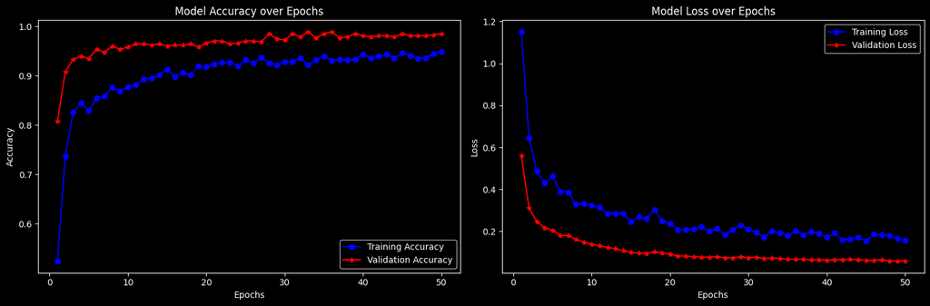

```python
plt.style.use('dark_background')

fig, (ax1, ax2) = plt.subplots(1, 2, figsize=(15, 5))
ax1.plot(epochs, accuracy, 'bo-', label='Training Accuracy')
ax1.plot(epochs, val_accuracy, 'r*-', label='Validation Accuracy')
ax1.set_title('Model Accuracy over Epochs')
ax1.set_xlabel('Epochs')
ax1.set_ylabel('Accuracy')
ax1.legend()

ax2.plot(epochs, loss, 'bo-', label='Training Loss')
ax2.plot(epochs, val_loss, 'r*-', label='Validation Loss')
ax2.set_title('Model Loss over Epochs')
ax2.set_xlabel('Epochs')
ax2.set_ylabel('Loss')
ax2.legend()

plt.tight_layout()
plt.show()
```

```python
predictions = model.predict(X_test)
predicted_classes = np.argmax(predictions, axis=1)
label_mapping = {0: 'Low', 1: 'Medium', 2: 'High'}

predicted_labels = [label_mapping[label] for label in predicted_classes]
actual_labels = [label_mapping[label] for label in y_test]

correct_predictions = sum(1 for i in range(len(predicted_labels)) if predicted_labels[i] == actual_labels[i])
total_predictions = len(predicted_labels)

# print("Predictions vs Actual Values:")
# for i in range(total_predictions):
#     print(f"Predicted: {predicted_labels[i]}, Actual: {actual_labels[i]}")

print(f"\nTotal correct predictions: {correct_predictions} / {total_predictions}")
```

```
15/15 ━━━━━━━━━━━━━━━━━━━━ 1s 10ms/step

Total correct predictions: 472 / 479
```

```python
from sklearn.metrics import accuracy_score, classification_report, confusion_matrix

accuracy = accuracy_score(y_test, predicted_classes)
print(f"\nModel Accuracy on Test Data: {accuracy:.2f}")
print("\nClassification Report:")
print(classification_report(y_test, predicted_classes, target_names=['Low', 'Medium', 'High']))
print("Confusion Matrix:")
print(confusion_matrix(y_test, predicted_classes))
```

```
Model Accuracy on Test Data: 0.99

Classification Report:
              precision    recall  f1-score   support

         Low       0.99      0.99      0.99       249
      Medium       0.98      0.99      0.98       214
        High       0.93      0.88      0.90        16

    accuracy                           0.99       479
   macro avg       0.97      0.95      0.96       479
weighted avg       0.99      0.99      0.99       479

Confusion Matrix:
[[247   2   0]
 [  2 211   1]
 [  0   2  14]]
```

## Comparative Table

[output not shown]